# Project 2: Data Mining, Classification, Prediction

SDS322E

# Mining, Classification, Prediction

## Alvin Kalathungal

### Introduction

So my last project revolved around COVID19, and I collected data about COVID and used R for my Pandemic Science. I was getting tired of looking at COVID19 data, and it is quite depressing. So I chose SMITE Data. SMITE is a third person multiplayer battle arena. Similar to Dota and League of Legends. It qualities are Gods and Monsters of myth as heros in the battlefield. As a nerdy kid who liked video games and mythos, Smite was one of my most played games when I was younger. I recently discovered that they are also adding other properties like RWBY and the Transformers. The main reason why I chose this dataset was due to the transformers advertisement I saw on Youtube and I thought it will be a good idea. Video games ususally have "Metas’ (not the mark zuckerberg metaverse), but a catalog of character that are ideal in battle. I was hoping to see correlations in the data and find if there is numbers to prove a meta.

```r
library(tidyverse)
library(dplyr)
library(knitr)
library(ggplot2)
# install.packages('maptools')
library(maptools)
# install.packages('mapdata')
library(mapdata)
# install.packages('ggthemes') install.packages('usmap')
library("usmap")
library(ggthemes)
# install.packages('tibble')
library(tibble)
# install.packages('viridis')
library(viridis)
# install.packages('readr')
library(readr)
library(cluster)
```

```r
smiteData <- read_csv("SmiteData.csv")
smiteData <- smiteData %>% select(1:4, 6, 8, 10, 12, 14, 16)
names(smiteData)[3] <- "dmgtype"
names(smiteData)[4] <- "baseHP"
names(smiteData)[8] <- "attackPersecond"
names(smiteData)[10] <- "portPHY"
head(smiteData)
```

```
## # A tibble: 6 x 10
##   `God Name` `God Class` dmgtype baseHP    MP Speed Range attackPersecond Damage
##   <chr>      <chr>       <chr>    <dbl> <dbl> <dbl> <dbl>           <dbl>  <dbl>
## 1 Agni       Mage        Magical    360   255   355    55            1        35
## 2 Ah Muzen … Hunter      Physic…    450   230   365    55            0.95     38
## 3 Ah Puch    Mage        Magical    400   265   365    55            0.86     37
## 4 Amaterasu  Warrior     Physic…    470   220   375    12            1        39
## 5 Anhur      Hunter      Physic…    460   220   365    55            0.9      42
## 6 Anubis     Mage        Magical    350   280   360    55            0.86     36
## # … with 1 more variable: portPHY <dbl>
```

Total attributes that were interesting and renamed columns for ease of use.

### Cluster Analysis

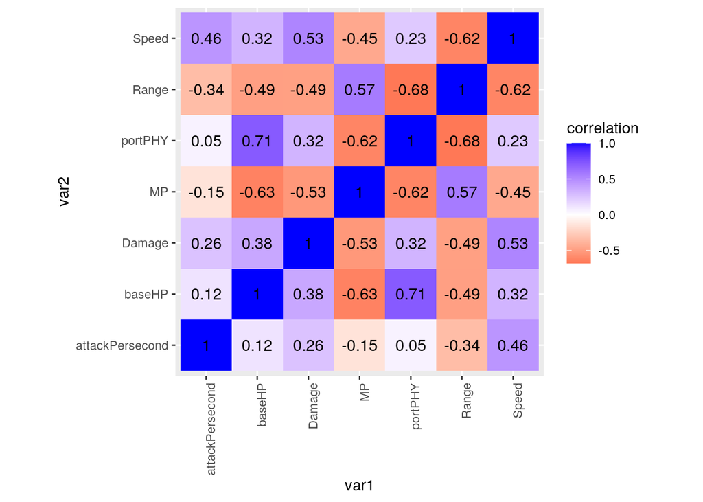

```r
library(cluster)

basicStats <- smiteData %>% select_if(is.numeric) %>% cor(use = "pair") %>%
    as.data.frame %>% rownames_to_column("var1") %>% pivot_longer(-1,
    names_to = "var2", values_to = "correlation")

basicStats %>% ggplot(aes(var1, var2, fill = correlation)) +
    geom_tile() + scale_fill_gradient2(low = "red", mid = "white",
    high = "blue") + geom_text(aes(label = round(correlation,
    2)), color = "black", size = 4) + theme(axis.text.x = element_text(angle = 90,
    hjust = 1)) + coord_fixed()
```

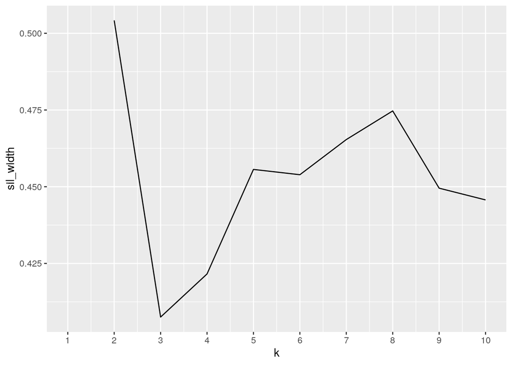

```r
sil_width <- vector()
for (i in 2:10) {
    pam_fit <- pam(smiteData, k = i)
    sil_width[i] <- pam_fit$silinfo$avg.width
}
ggplot() + geom_line(aes(x = 1:10, y = sil_width)) + scale_x_continuous(name = "k",
    breaks = 1:10)
```

```r
smite_pam <- smiteData %>% pam(k = 2)
smite_pam
```

```
## Medoids:
##      ID God Name God Class dmgtype baseHP  MP Speed Range attackPersecond
## [1,] 65       NA        NA      NA    385 255   360    55            0.88
## [2,] 15       NA        NA      NA    475 220   370    16            1.00
##      Damage portPHY
## [1,]     35      11
## [2,]     38      13
## Clustering vector:
##  [1] 1 2 1 2 2 1 1 1 2 2 2 2 2 2 2 2 2 1 2 2 2 2 2 2 2 1 2 2 2 2 2 2 1 2 2 2 2 1
## [39] 1 1 2 2 2 1 2 1 2 2 2 1 2 2 1 2 1 1 1 2 2 1 1 2 2 1 1 1 2 2 2 1 1 2 2 1 2 2
## [77] 2 2 1 1 2 1 2 2 2 1 2 2 2 1 2
## Objective function:
##    build     swap
## 44.07944 42.41349
##
## Available components:
##  [1] "medoids"    "id.med"     "clustering" "objective"  "isolation"
##  [6] "clusinfo"   "silinfo"    "diss"       "call"       "data"
```

```r
smiteData %>% slice(smite_pam$id.med)
```

```
## # A tibble: 2 x 10
##   `God Name` `God Class` dmgtype baseHP    MP Speed Range attackPersecond Damage
##   <chr>      <chr>       <chr>    <dbl> <dbl> <dbl> <dbl>           <dbl>  <dbl>
## 1 Ra         Mage        Magical    385   255   360    55            0.88     35
## 2 Awilix     Assassin    Physic…    475   220   370    16            1        38
## # … with 1 more variable: portPHY <dbl>
```

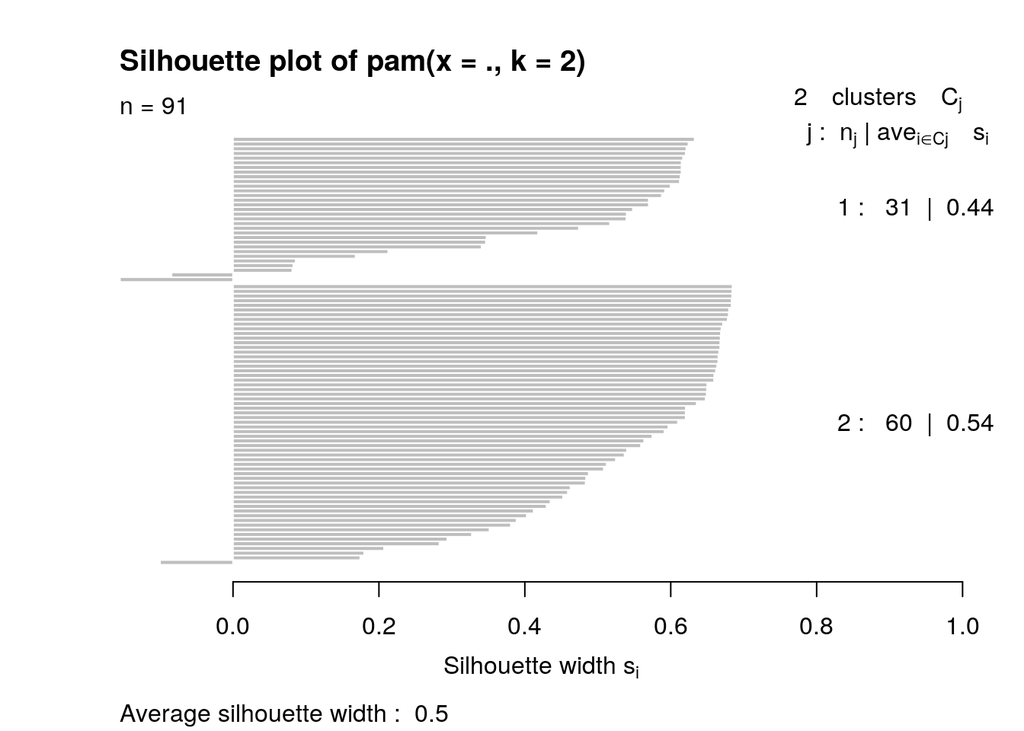

```r
plot(smite_pam, which = 2)
```

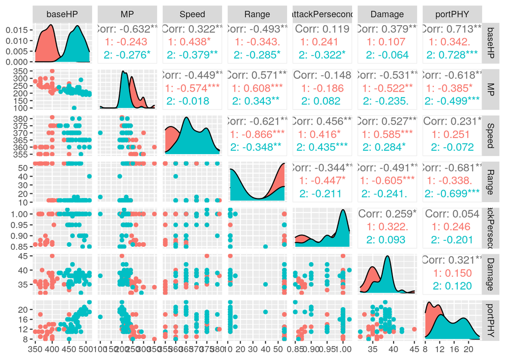

```r
library(GGally)
smiteClust <- smiteData %>% mutate(cluster = as.factor(smite_pam$clustering))
ggpairs(smiteClust, columns = 4:10, aes(color = cluster))
```

Did a correlation matrix to see a if there any basic correlations. We see portPHy and BaseHp are correlated at 0.71. Make sense are physical protections and base Hp go hand in hand. We see range is portPHY is negatively correlated. ranged characters would have weaker protections. We picked the number of clusters by graphing sil_width with PAM. K=2. We see the gods Ra ( Class: Mage Dmgtype: magical) and Awillix ( Class: Assassin, DMg: type: Physical) We got an average sil_wid of 0.5 whcih is weak associations. When using GGpairs, we see that portpHy is correlated at 0.713. MP and Range are negatively correlated with PortPHy. Speed and Range are negatively correlated. This all makes sense game wise, ranged characters are slower. if they were faster, they would have been overpowered in the game. Overall, the data proven to make sense.

### Dimensionality Reduction with PCA

```r
pca1 <- princomp(smiteData[4:10], cor = TRUE)
summary(pca1, loadings = T)
```

```
## Importance of components:
##                           Comp.1    Comp.2     Comp.3     Comp.4     Comp.5
## Standard deviation     1.9139954 1.1364592 0.82881889 0.70573714 0.62798834
## Proportion of Variance 0.5233398 0.1845057 0.09813439 0.07115213 0.05633848
## Cumulative Proportion  0.5233398 0.7078454 0.80597980 0.87713193 0.93347041
##                            Comp.6    Comp.7
## Standard deviation     0.57419260 0.3687953
## Proportion of Variance 0.04709959 0.0194300
## Cumulative Proportion  0.98057000 1.0000000
##
## Loadings:
##                 Comp.1 Comp.2 Comp.3 Comp.4 Comp.5 Comp.6 Comp.7
## baseHP           0.395  0.354  0.171  0.432  0.328  0.546  0.312
## MP              -0.426 -0.190  0.211 -0.223 -0.309  0.767
## Speed            0.365 -0.452 -0.153 -0.375  0.575  0.225 -0.343
## Range           -0.444        -0.197  0.577  0.283        -0.587
## attackPersecond  0.204 -0.634  0.550  0.452 -0.167 -0.135
## Damage           0.363 -0.198 -0.680  0.255 -0.507  0.206
## portPHY          0.398  0.434  0.315 -0.145 -0.319        -0.657
```

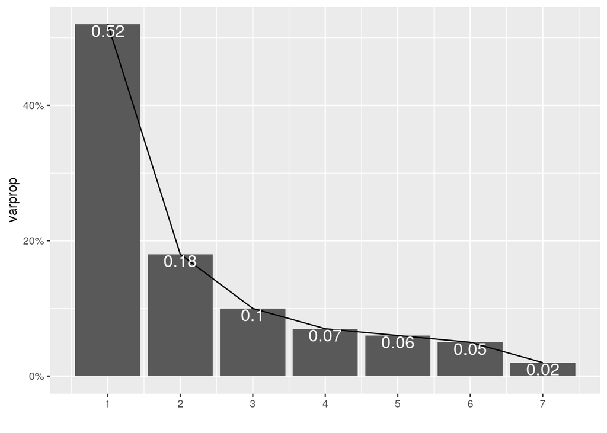

```r
eigval <- pca1$sdev^2  #square to convert SDs to eigenvalues
varprop = round(eigval/sum(eigval), 2)  #proportion of var explained by each PC

ggplot() + geom_bar(aes(y = varprop, x = 1:7), stat = "identity") +
    xlab("") + geom_path(aes(y = varprop, x = 1:7)) + geom_text(aes(x = 1:7,
    y = varprop, label = round(varprop, 2)), vjust = 1, col = "white",
    size = 5) + scale_y_continuous(breaks = seq(0, 0.6, 0.2),
    labels = scales::percent) + scale_x_continuous(breaks = 1:10)
```

```r
round(cumsum(eigval)/sum(eigval), 2)
```

```
## Comp.1 Comp.2 Comp.3 Comp.4 Comp.5 Comp.6 Comp.7
##   0.52   0.71   0.81   0.88   0.93   0.98   1.00
```

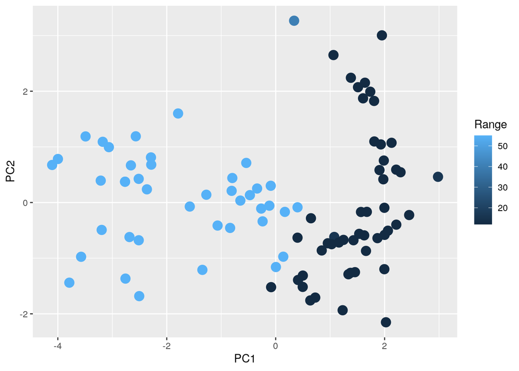

```r
results <- smiteData %>% as.data.frame %>% mutate(PC1 = pca1$scores[,
    1], PC2 = pca1$scores[, 2], PC3 = pca1$scores[, 3], PC4 = pca1$scores[,
    4])  #add PCs

results %>% ggplot(aes(PC1, PC2, color = Range)) + geom_point(size = 4)
```

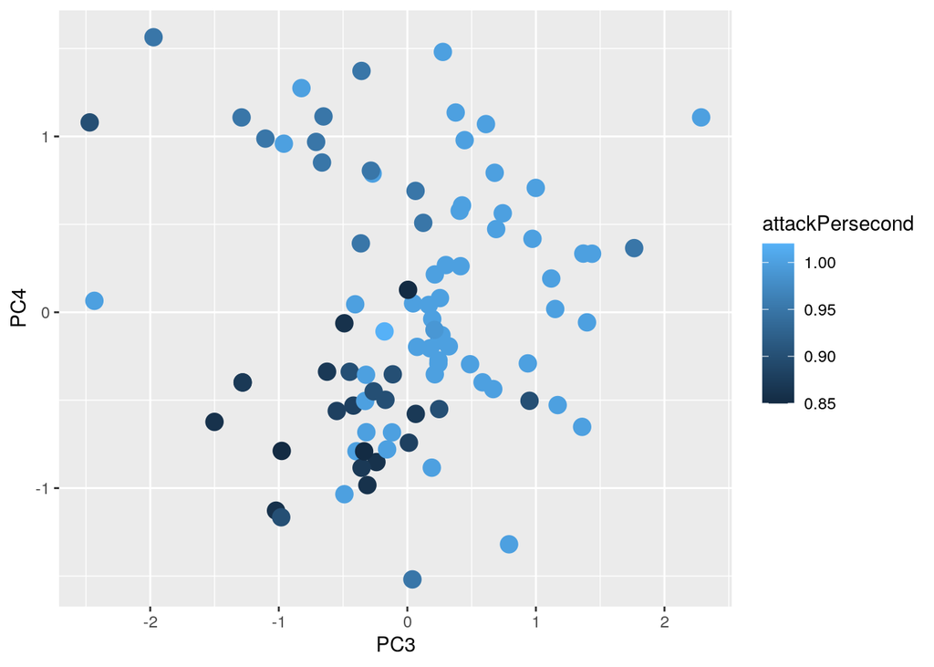

```r
results %>% ggplot(aes(PC3, PC4, color = attackPersecond)) +
    geom_point(size = 4)
```

The first ggplot we can see huge correlation with range. The second ggplot which acounts for PCA 3 and PCA 4 accounts for AttackperSecond.

The Princomp ran with columns 4:10 which wre the numeric variables. and wehen running the PCA,we see that by PCA 3, we see that 80.5% of the data is understood by then. We can keep up to PCA 3, though I did use up to PCA 4 for the ggplots. We see the that first PCA accounted for 52% when mainly removing MP and Range. The second PCA mainly removed Speed and Attack per second. Rhe there added attack per second and removed Damage. For the first PCa, it make senese, relative good HP would mean you are in frontlines, so your magical use is weaker and involved main damage. The second PCA we see a re low of attack per second, being at -0.634. and high value being 0.434. This confuses me slightly, but I can see heavier characters do slower atttack in the front lines but which would require physical resistance. The third PCA acounts for 80.5% and we see a high of attack per second, with a low damage. These would be the spammy character who shoot a lot but doesn’t do a lot of damage. The damage adds over time.

The First PCA accounts for 52% if the variance, PCA2 accounts for 0.18. PCA3 accounts for 0.1. PCA 4 acounts for 0.07. So the first 4 PCAs accounts for 87% of the total variance.

### Linear Classifier

```r
classData <- smiteData %>% select(3:10)
classData <- classData %>% mutate(dmgtype = ifelse(dmgtype ==
    "Physical", 1, 0))

fit <- glm(dmgtype ~ ., data = classData, family = "binomial")
probs <- predict(fit, type = "response")
class_diag(probs, classData$dmgtype, positive = "1")
```

```
##            acc   sens   spec  ppv     f1     ba    auc
## Metrics 0.9231 0.9388 0.9048 0.92 0.9293 0.9218 0.9893
```

```r
table(truth = classData$dmgtype, predictions = probs > 0.5)
```

```
##      predictions
## truth FALSE TRUE
##     0    38    4
##     1     3   46
```

```r
smitedata2 <- smiteData %>% mutate(dmgtype = ifelse(dmgtype ==
    "Physical", 1, 0)) %>% select(3:10)
```

```r
set.seed(321)
k = 10

data <- sample_frac(smitedata2)  #randomly order rows
folds <- rep(1:k, length.out = nrow(data))  #create folds

diags <- NULL

i = 1
for (i in 1:k) {
    train <- data[folds != i, ]
    test <- data[folds == i, ]
    truth <- test$dmgtype

    fit <- glm(dmgtype ~ ., data = train, family = "binomial")


    probs <- predict(fit, newdata = test, type = "response")

    diags <- rbind(diags, class_diag(probs, truth, positive = "1"))
}

# average performance metrics across all folds
summarize_all(diags, mean)
```

```
##       acc    sens    spec     ppv      f1      ba     auc
## 1 0.89112 0.95143 0.87047 0.85833 0.88598 0.91095 0.94821
```

### Non-Parametric Classifier

```r
library(caret)
fit <- knn3(dmgtype ~ ., data = classData)
probs <- predict(fit, newdata = classData)[, 2]
class_diag(probs, classData$dmgtype, positive = "1")
```

```
##           acc sens   spec    ppv     f1     ba    auc
## Metrics 0.956    1 0.9048 0.9245 0.9608 0.9524 0.9951
```

```r
table(truth = classData$dmgtype, predictions = probs > 0.5) %>%
    addmargins
```

```
##      predictions
## truth FALSE TRUE Sum
##   0      38    4  42
##   1       0   49  49
##   Sum    38   53  91
```

```r
set.seed(322)
k = 10

data <- sample_frac(smitedata2)
folds <- rep(1:k, length.out = nrow(data))

diags <- NULL

i = 1
for (i in 1:k) {
    # create training and test sets
    train <- data[folds != i, ]
    test <- data[folds == i, ]
    truth <- test$dmgtype

    # train model
    fit <- knn3(dmgtype ~ ., data = train)  ### SPECIFY THE KNN MODEL FIT TO THE TRAINING SET HERE

    # test model
    probs <- predict(fit, newdata = test)[, 2]
    ### GET PREDICTIONS FROM THE TRAINED MODEL ON THE TEST SET HERE

    # get performance metrics for each fold
    diags <- rbind(diags, class_diag(probs, truth, positive = "1"))
}

# average performance metrics across all folds
summarize_all(diags, mean)
```

```
##       acc sens    spec     ppv      f1      ba     auc
## 1 0.93445 0.98 0.86571 0.89627 0.92992 0.92286 0.98264
```

### Regression/Numeric Prediction

```r
fit <- lm(baseHP ~ ., data = smiteData)
yhat <- predict(fit)
mean((smiteData$baseHP - yhat)^2)
```

```
## [1] 7.542839e-25
```

```r
set.seed(322)
k = 2  #choose number of folds
data <- smitedata2[sample(nrow(smitedata2)), ]  #randomly order rows
folds <- cut(seq(1:nrow(smitedata2)), breaks = k, labels = F)  #create folds
diags <- NULL
for (i in 1:k) {
    train <- data[folds != i, ]
    test <- data[folds == i, ]
    ## Fit linear regression model to training set
    fit <- lm(baseHP ~ ., data = train)
    ## Get predictions/y-hats on test set (fold i)
    yhat <- predict(fit, newdata = test)
    ## Compute prediction error (MSE) for fold i
    diags <- mean((test$baseHP - yhat)^2)
}
mean(diags)
```

```
## [1] 1146.37
```

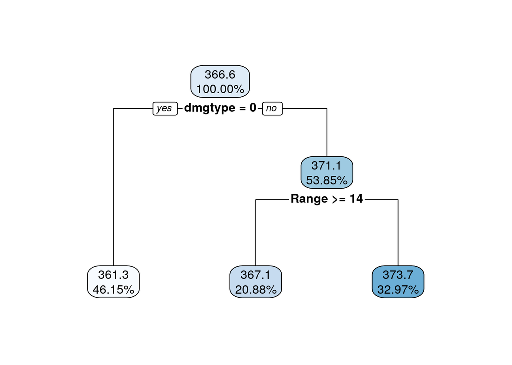

```r
library(rpart)
library(rpart.plot)

fit <- train(Speed ~ ., data = smitedata2, method = "rpart")
rpart.plot(fit$finalModel, digits = 4)
```

I decided to do both a tree and the model. Though my main focus was the model and BaseHP of characters. The model gave use a MSE 7.54*10^-25. So it was pretty accurate. When doing the fold at k=2, we see the mean goes to 1146, which means it is drastically over fittings. This models shows drastic signs of overfitting. The tree was made to understand speed.

### Python

```r
# R code chunk
library(reticulate)
use_python("/usr/bin/python3")

pythondata <- smiteData$attackPersecond
```

```python
## Python code chunk
import numpy as np
data=(r.pythondata)

#print(data)

dataMedian = (np.median(data))
print(dataMedian)
```

```
## 1.0
```

```python
dataMean = (np.mean(data))
print(dataMean)
```

```
## 0.9604395604395605
```

```python
dataVar =(np.var(data))
print(dataVar)
```

```
## 0.0028987078855210718
```

```python
dataMin = min(data)
print(dataMin)
```

```
## 0.85
```

```python
dataMax = max(data)
print(dataMax)
```

```
## 1.02
```

```r
sumATKPerSec = c(py$dataMin, py$dataMean, py$dataMedian, py$dataMax,
    py$dataVar)
sumATKPerSec
```

```
## [1] 0.850000000 0.960439560 1.000000000 1.020000000 0.002898708
```

Python: I didn’t think anyway to be creative for the python section of this project so I decided to replicate what was done in the homework. I was interested in seeing attack per second reflected the smite characters. I grabbed that smite$attackPersecond from python. Moved it to python. Python calculated the values and I grabbed them in R and displayed them in their own variable.

### Concluding Remarks

Overall, the smite dataset is fascinating. I am quite happy the developers made a lot of sense in their character creation process.

This was a fun project and I have learned a lot about R through these two projects and in class (through zoom or in-person). I hope to expand this knowledge in the future and use it in my future careers. Maybe grad school if I so choose to go. I am still deciding on that even though I am graduating in May. Have a good holiday break Professor Woodward and Mr. Han. Thank you for the knowledge you have bestowed.